# lab7

PSTAT W 174/274

Sandy Gao

2023-11-17

We will continue to analyze adjusted monthly milk production measured in pounds per from Jan. 1962 to Dec. 1975. And we can import the dataset from tsdl package as milk in R, and denote the milk time series as Xt. For comparison, we split the dataset into training set train and testing set test. The training set is used for model building, and the testing set is used for prediction verification and comparison.

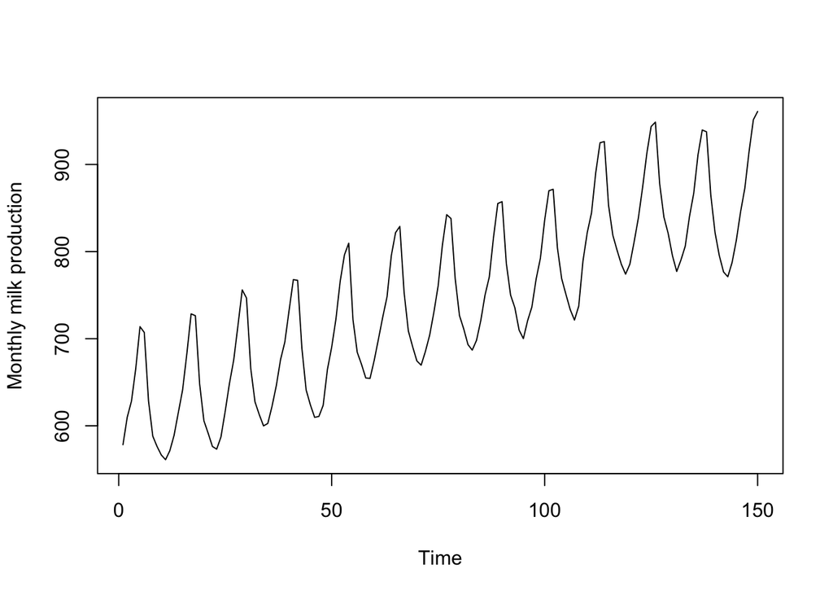

```r
library(tsdl)
milk <- subset(tsdl, 12, "Agriculture")[[3]]
train <- milk[1:150]
test <- milk[151:156]
ts.plot(train, ylab = "Monthly milk production")
```

From the above graph, we can conclude that Xt is non-stationary because of the upward trend and seasonality. (You can think about whether we need to transform the series or not.) To make it more stationary, we need to remove trend and seasonality with the following code:

```r
dmilk <- diff(train, 12)
ddmilk <- diff(dmilk, 1)
```

Let Yt denote the series ddmilk. Then, Yt = (1 − B)(1 − B12)Xt. As Lab Assignment 5 and 6, we choose SARIMA(0, 1, 0) × (0, 1, 1)12 as our final model. Now, we will conduct model diagnostic analysis.